# BDCC-Final-Project

```python
from IPython.display import display, HTML
HTML(
    """
    <script
        src='https://cdnjs.cloudflare.com/ajax/libs/jquery/2.0.3/jquery.min.js'>
    </script>
    <script>
        code_show=true;
        function code_toggle() {
        if (code_show){
        $('div.jp-CodeCell > div.jp-Cell-inputWrapper').hide();
        } else {
        $('div.jp-CodeCell > div.jp-Cell-inputWrapper').show();
        }
        code_show = !code_show
        }
        $( document ).ready(code_toggle);
    </script>
    <form action='javascript:code_toggle()'>
        <input type="submit" value='Click here to toggle on/off the raw code.'>
    </form>
    """
)
```

```python
sc.install_pypi_package('numpy');
sc.install_pypi_package('pandas');
sc.install_pypi_package('matplotlib');
sc.install_pypi_package('wordcloud');
sc.install_pypi_package('pyarrow');
```

```python
from pyspark.sql import SparkSession
from pyspark.sql.types import (
    StructType,
    StructField,
    StringType,
    IntegerType,
    FloatType,
    DoubleType,
)
from pyspark.sql import functions as F
from pyspark.ml.feature import (
    VectorAssembler,
    OneHotEncoder,
    StringIndexer,
    MinMaxScaler,
    Bucketizer,
)
from pyspark.ml import Pipeline, PipelineModel
from pyspark.ml.regression import (
    RandomForestRegressor,
    LinearRegression,
)
from pyspark.ml.evaluation import RegressionEvaluator
from pyspark.ml.tuning import CrossValidatorModel, ParamGridBuilder
from pyspark.ml.linalg import VectorUDT
from pyspark.ml.stat import Correlation

import pandas as pd
import numpy as np

import matplotlib.pyplot as plt
from wordcloud import WordCloud
import math
```

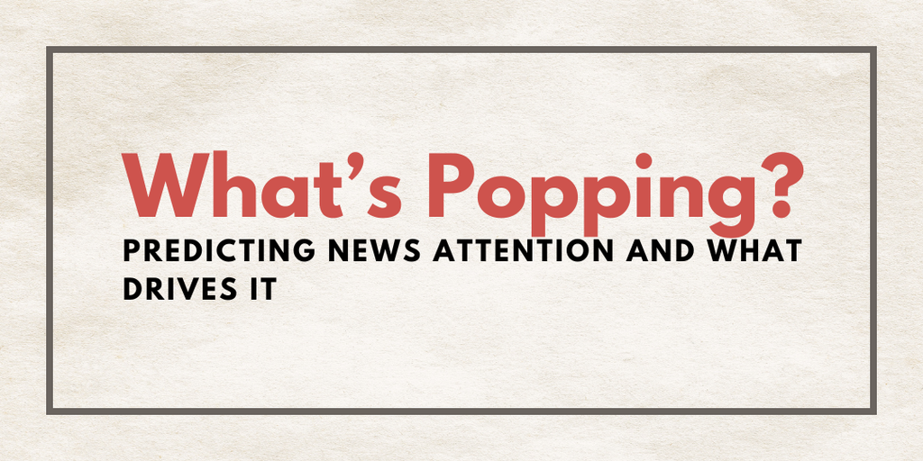

```python
from IPython.display import Image
Image(filename="title.png", width=10000, height=250)
```

# Abstract

This study focuses on developing predictive models to estimate the number of mentions within the Global Database of Events, Language, and Tone (GDELT) dataset. GDELT is a comprehensive collection of global news and events, documented from various sources around the world. Leveraging big data and cloud computing technologies, we aim to gain valuable insights into trends of real-world events. Our study encompasses the following areas:

- Predictive Modeling: Implementing and evaluating different machine learning models to accurately predict number of mentions.
- Feature Importance: By determining the most influential factors that affects the mention counts, we aim to uncover patterns in global news dissemination
- Big Data Integration: Utilization of cloud computing resources to manage and process the vast GDELT dataset efficiently.

# Introduction

In this age of information, the volume of data that is generated daily is constantly increasing. According to the report of IDC (2017), the global data quantity is projected to reach 175 zettabytes by 2025. This vast information includes news data, which is crucial on shaping the views and understanding of the public about the worldwide events. There are uncountable events happening all of the time, and it is impossible to pay attention to everything. Instead, we would like to filter this to identify important news for our further attention.

The GDELT project is a prime example of this valuable data, collecting news data from broadcasts, print, and web sources globally. Currently, the GDELT project has a collection of quarter-billion data points, which makes it a rich repository for exploring global events and societal trends (GDELT, n.d.). Unlike older projects that could only work on the english language internet, GDELT 2.0, launched in 2015, uses real time translations to include 65 foreign languages and news published in those languages to the database.

However, a crucial aspect of analyzing the GDELT data lies in understanding the significance of specific events. There are three metrics in the GDELT to predict event importance; Number of Mentions, Sources, and Articles. For this study, we aim to predict the number of mentions to better reflect not only the articles that specifically talk about this event, but also to capture related events that reference this event. This would allow us to predict and understand global developments and to identify key features that could be driving these mentions which would provide a deeper understanding of global news patterns.

# Problem Statement

Can we create a machine learning model to predict the number of mentions that a news event will have and use this model to explain the impact of event characteristics on the number of mentions of the event as a proxy for the importance of an event?

# Motivation

The ability to predict and analyze the number of mentions in global news can help improve the flow of information, identify emerging trends, and improve decisionmaking in domains such as public policy and business strategy. By leveraging big data and cloud computing, this project seeks to use the rich data of GDELT to provide actionable insights for data-driven decision making. The outcome of this project will not only contribute to academic knowledge but also offer practical benefits for the stakeholders that relies on timely and relevant news data.

# Data Decription

## Data Source

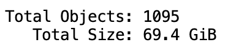

```python
Image(filename="filesize.png")
```

## Data Scope and Limitations

For this project, we focused on a subset of the GDELT dataset. The analysis was conducted only using data from July 2016 to July 2019. In addition, we only considered several features for our analysis, namely:

- GoldsteinScale
- Actor1Code_ind
- Actor1Name_ind
- Actor1CountryCode_ind
- Actor1Type1Code_ind
- IsRootEvent_ind
- EventCode_ind
- EventBaseCode_ind
- EventRootCode_ind
- QuadClass_ind

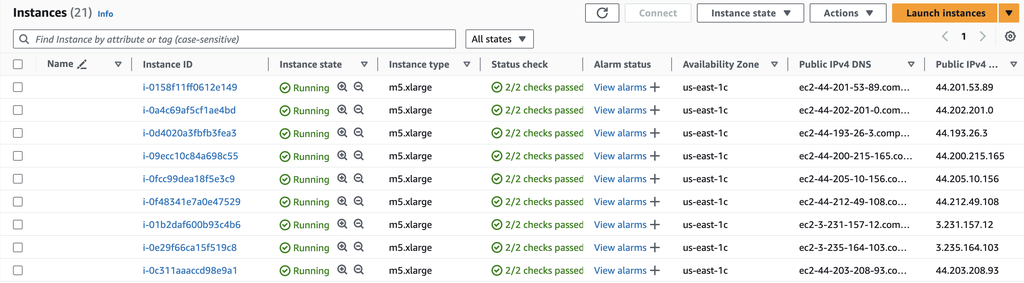

```python
Image(filename="instance.png")
```

## Data Overview

The GDELT (Global Database of Events, Language, and Tone) dataset is a comprehensive, open-source dataset that records global events and their attributes. This dataset is used to predict the number of mentions of events and explore the features influencing these mentions. Table 1 shows the overview of the description of the columns within the original GDELT dataset.

**Table 1. Original GDELT Data Overview**

| Column | Description | Column | Description |
| --- | --- | --- | --- |
| GLOBALEVENTID | Unique identifier for each event. | EventBaseCode | The base CAMEO event code. |
| SQLDATE | The date of the event in YYYYMMDD format. | EventRootCode | The root CAMEO event code. |
| Actor1Code | The code for the first actor involved in the event. | QuadClass | The CAMEO quad class of the event, categorizing it into one of four categories: Verbal Cooperation, Material Cooperation, Verbal Conflict, or Material Conflict. |
| Actor1Name | The name of the first actor involved in the event. | GoldsteinScale | A numeric score measuring the impact of the event. Positive values indicate cooperative events, while negative values indicate conflict events. |
| Actor1CountryCode | The country code of the first actor involved in the event. | NumMentions | The number of mentions of the event across sources. |
| Actor1Type1Code | The type code of the first actor involved in the event. | NumSources | The number of distinct sources reporting the event. |
| Actor2Code | The code for the second actor involved in the event. | NumArticles | The number of distinct articles discussing the event. |
| Actor2Name | The name of the second actor involved in the event. | AvgTone | The average tone of the coverage on the event, where higher values indicate more positive sentiment and lower values indicate more negative sentiment. |
| Actor2CountryCode | The country code of the second actor involved in the event. | Actor1Geo_Type | The geographic type of the first actor involved in the event (e.g., country, city). |
| Actor2Type1Code | The type code of the second actor involved in the event. | Actor1Geo_FullName | The full geographic name of the first actor's location. |
| IsRootEvent | Indicates whether this event is the root event (1) or not (0). | Actor1Geo_CountryCode | The country code of the first actor's location. |
| EventCode | The CAMEO event code describing the type of event. | Actor1Geo_ADM1Code | The administrative division code of the first actor's location. |
| Actor1Geo_Lat | The latitude of the first actor's location. | ActionGeo_Type | The geographic type of the event's location (e.g., country, city). |
| Actor1Geo_Long | The longitude of the first actor's location. | ActionGeo_FullName | The full geographic name of the event's location. |
| Actor1Geo_FeatureID | The geographic feature ID of the first actor's location. | ActionGeo_CountryCode | The country code of the event's location. |
| Actor2Geo_Type | The geographic type of the second actor involved in the event (e.g., country, city). | ActionGeo_ADM1Code | The administrative division code of the event's location. |
| Actor2Geo_FullName | The full geographic name of the second actor's location. | ActionGeo_Lat | The latitude of the event's location. |
| Actor2Geo_CountryCode | The country code of the second actor's location. | ActionGeo_Long | The longitude of the event's location. |
| Actor2Geo_ADM1Code | The administrative division code of the second actor's location. | ActionGeo_FeatureID | The geographic feature ID of the event's location. |
| Actor2Geo_Lat | The latitude of the second actor's location. | DATEADDED | The date the event was added to the GDELT database. |
| Actor2Geo_Long | The longitude of the second actor's location. | SOURCEURL | The URL of the source article that reported the event. |
| Actor2Geo_FeatureID | The geographic feature ID of the second actor's location. |  |  |

# Methodology

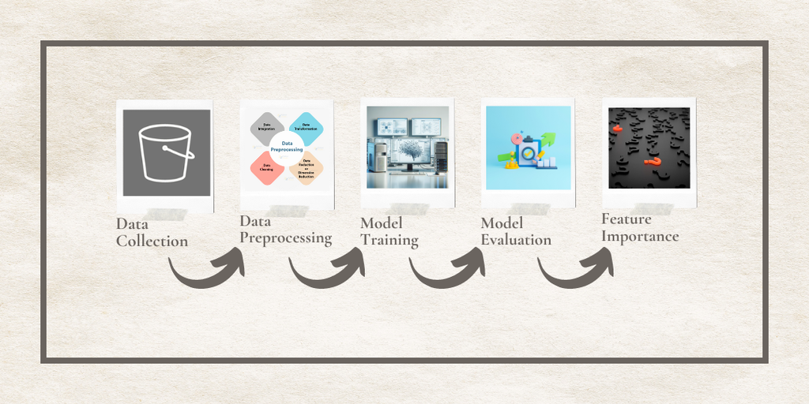

```python
Image(filename="method.png", width=10000, height=250)
```

**Figure 1. Methodology Overview**

## Overview

The methodology for this project was structured into five main steps as shown in Figure 1.

All of the tasks was done using Apache Spark to enable efficient handling and processing of the big dataset.

## Detailed

### Data Collection

The GDelt dataset was collected from its own public amazon [s3 bucket](https://aws.amazon.com/marketplace/pp/prodview-fmgfyur32mb3m) and then transferred to our own S3 bucket. The dataset consists of 1,095 files in total, spanning the period from July 01, 2016, to July 01, 2019 (three years' worth of data). For a more detailed description of the data collection process, please refer to the `file_transfer.ipynb` file.

Once the data was collected, the first thing we did is to extract the necessary dataset from it. Since the data has no column name, we collected its column labels from [GDELT Website](https://www.gdeltproject.org/data/lookups/CSV.header.dailyupdates.txt). Once we were able to rename the dataset, we based the importance of the columns from the [GDELT Data Format Documentation](http://data.gdeltproject.org/documentation/GDELT-Data_Format_Codebook.pdf). Having chosen the appropriate columns needed for prediction, we selected those columns and dropped all of their null values. This resulted in a usable dataset in Parquet format. Table 2 shows the columns we expect to use.

*Note: For a better extraction of the data, please see the `data_extraction.ipynb` file.*

**Table 2. Processed GDELT Data Overview**

| variables | description |
| --- | --- |
| Actor1Code | raw CAMEO code for Actor1 |
| IsRootEvent | a proxy for the rough importance of an event |
| Actor1Name | The actual name of the Actor 1 |
| EventCode | This is the raw CAMEO action code describing the action that Actor1 performed |
| Actor1CountryCode | The 3-character CAMEO code for the country affiliation of Actor1. |
| Actor1Type1Code | CAMEO event codes are defined in a three-level taxonomy |
| EventRootCode | defines the root-level category the event code falls under |
| GoldsteinScale | Each CAMEO event code is assigned a numeric score from -10 to +10, capturing the theoretical potential impact that type of event will have on the stability of a country |
| QuadClass | The entire CAMEO event taxonomy is ultimately organized under four primary classifications: Verbal Cooperation, Material Cooperation, Verbal Conflict, and Material Conflict. |
| NumMentions(target) | This is the total number of mentions of this event across all source documents. |

### Data Exploration

Before diving into analysis, we need to explore the data have an understanding on its structure and contents. This is crucial for the preprocessing step.

Our initial step is to initialize a SparkSession. Then, we load the subset of the GDELT data set that was saved as parquet files.

```python
spark = (SparkSession
         .builder
         .master('yarn')
         .config('spark.sql.execution.arrow.pyspark.enabled', 'true')
         .getOrCreate());
```

```
VBox()
```

```
FloatProgress(value=0.0, bar_style='info', description='Progress:', layout=Layout(height='25px', width='50%'),…
```

```python
schema = StructType([
    StructField("GLOBALEVENTID", StringType(), True),
    StructField("Actor1Code", StringType(), True),
    StructField("Actor1Name", StringType(), True),
    StructField("Actor1CountryCode", StringType(), True),
    StructField("Actor1Type1Code", StringType(), True),
    StructField("IsRootEvent", StringType(), True),
    StructField("EventCode", StringType(), True),
    StructField("EventBaseCode", StringType(), True),
    StructField("EventRootCode", StringType(), True),
    StructField("QuadClass", StringType(), True),
    StructField("GoldsteinScale", StringType(), True),
    StructField("NumMentions", StringType(), True),
    StructField("Year", IntegerType(), True)
]);
```

```
VBox()
```

```
FloatProgress(value=0.0, bar_style='info', description='Progress:', layout=Layout(height='25px', width='50%'),…
```

```python
df = spark.read.schema(schema).parquet('s3://bdcc2024-fp/final_parquet');
```

```
VBox()
```

```
FloatProgress(value=0.0, bar_style='info', description='Progress:', layout=Layout(height='25px', width='50%'),…
```

#### Schema Inspection

We begin by inspecting the schema of the dataset to understand the structure and types of each column. The current schema of the GDELT dataset is shown below.

```python
df.printSchema();
```

```
VBox()
```

```
FloatProgress(value=0.0, bar_style='info', description='Progress:', layout=Layout(height='25px', width='50%'),…
```

[output not shown]

#### Sample Row Examination

Next, we can check the first entry of the data to see what the data looks like. An example row from the dataset is as follows:

```python
df.show(1, vertical=True, truncate=False);
```

```
VBox()
```

```
FloatProgress(value=0.0, bar_style='info', description='Progress:', layout=Layout(height='25px', width='50%'),…
```

```
-RECORD 0----------------------
 GLOBALEVENTID     | 572067649
 Actor1Code        | AFGGOV
 Actor1Name        | AFGHAN
 Actor1CountryCode | AFG
 Actor1Type1Code   | GOV
 IsRootEvent       | 0
 EventCode         | 030
 EventBaseCode     | 030
 EventRootCode     | 03
 QuadClass         | 1
 GoldsteinScale    | 4.0
 NumMentions       | 6
 SQLDATE           | 20160824
 Year              | 2016
only showing top 1 row
```

#### Summary Statistics

We generated summary statistics to gain insights into the distribution, central tendency, and dispersion of the numerical columns in our dataset, which is shown below.

```python
df.describe().show(truncate=False, vertical=True)
```

```
VBox()
```

```
FloatProgress(value=0.0, bar_style='info', description='Progress:', layout=Layout(height='25px', width='50%'),…
```

```
-RECORD 0----------------------------------
 summary           | count
 GLOBALEVENTID     | 22704441
 Actor1Code        | 22704441
 Actor1Name        | 22704441
 Actor1CountryCode | 22704441
 Actor1Type1Code   | 22704441
 IsRootEvent       | 22704441
 EventCode         | 22704441
 EventBaseCode     | 22704441
 EventRootCode     | 22704441
 QuadClass         | 22704441
 GoldsteinScale    | 22704441
 NumMentions       | 22704441
 SQLDATE           | 22704441
 Year              | 22704441
-RECORD 1----------------------------------
 summary           | mean
 GLOBALEVENTID     | 7.064562051427234E8
 Actor1Code        | NULL
 Actor1Name        | NULL
 Actor1CountryCode | NULL
 Actor1Type1Code   | NULL
 IsRootEvent       | 0.6458906431565525
 EventCode         | 96.9865269530309
 EventBaseCode     | 68.40265893355401
 EventRootCode     | 6.656606652416591
 QuadClass         | 1.784764531309095
 GoldsteinScale    | 0.5585286420399204
 NumMentions       | 13.418690422723907
 SQLDATE           | 2.017468625447788E7
 Year              | 2017.4020121437916
-RECORD 2----------------------------------
 summary           | stddev
 GLOBALEVENTID     | 8.781090861052077E7
 Actor1Code        | NULL
 Actor1Name        | NULL
 Actor1CountryCode | NULL
 Actor1Type1Code   | NULL
 IsRootEvent       | 0.47824254339507233
```

[output cut: 25 more lines]

```
 summary           | max
 GLOBALEVENTID     | 856339794
 Actor1Code        | bihSEACRM
 Actor1Name        | ZYGIMANTAS PAVILIONIS
 Actor1CountryCode | ZWE
 Actor1Type1Code   | UIS
 IsRootEvent       | 1
 EventCode         | 203
 EventBaseCode     | 203
 EventRootCode     | 20
 QuadClass         | 4
 GoldsteinScale    | 9.0
 NumMentions       | 999
 SQLDATE           | 20190701
 Year              | 2019
```

#### Missing Values

Identifying missing values is a crucial step in data preprocessing. We examined the dataset for any missing values to ensure data quality and completeness.

```python
df.select([F.count(F.when(F.isnan(c) | F.col(c).isNull(), c)).alias(c)
           for c in df.columns]).show(truncate=False, vertical=True);
```

```
VBox()
```

```
FloatProgress(value=0.0, bar_style='info', description='Progress:', layout=Layout(height='25px', width='50%'),…
```

```
-RECORD 0----------------
 GLOBALEVENTID     | 0
 Actor1Code        | 0
 Actor1Name        | 0
 Actor1CountryCode | 0
 Actor1Type1Code   | 0
 IsRootEvent       | 0
 EventCode         | 0
 EventBaseCode     | 0
 EventRootCode     | 0
 QuadClass         | 0
 GoldsteinScale    | 0
 NumMentions       | 0
 SQLDATE           | 0
 Year              | 0
```

#### Distribution of Events per Year

To understand the annual distribution of events, we plotted the number of events per year. The figure below shows the distribution of events over the years, highlighting the time period from 2016 to 2019:

```python
#Convert SQLDATE from Integer to String and then to Date
df = (df.withColumn("SQLDATE", F.to_date(F.col("SQLDATE").cast("string"),
                                         "yyyyMMdd")));
```

```
VBox()
```

```
FloatProgress(value=0.0, bar_style='info', description='Progress:', layout=Layout(height='25px', width='50%'),…
```

```
VBox()
```

```
FloatProgress(value=0.0, bar_style='info', description='Progress:', layout=Layout(height='25px', width='50%'),…
```

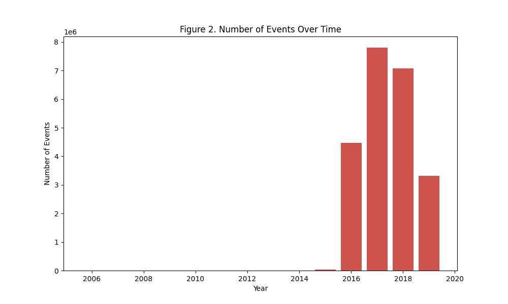

```python
events_per_year = (df.groupBy(F.year("SQLDATE").alias("Year"))
                   .count().orderBy("Year").toPandas());

plt.figure(figsize=(10, 6))
plt.bar(events_per_year["Year"], events_per_year["count"], color="#CE534D")
plt.xlabel("Year")
plt.ylabel("Number of Events")
plt.title("Figure 2. Number of Events Over Time")
plt.show();

%matplot plt
```

- The number of recorded events peaked in 2017 and 2018, followed by a noticeable decline in 2019.

#### Top 10 Actors by Count

Next, we looked the top 10 actors by count. This analysis provided insights into the key entities that dominate the GDELT dataset.

```python
top_actors = (df.groupBy("Actor1Name").count()
              .orderBy("count", ascending=False).limit(10).toPandas());
```

```
VBox()
```

```
FloatProgress(value=0.0, bar_style='info', description='Progress:', layout=Layout(height='25px', width='50%'),…
```

```
VBox()
```

```
FloatProgress(value=0.0, bar_style='info', description='Progress:', layout=Layout(height='25px', width='50%'),…
```

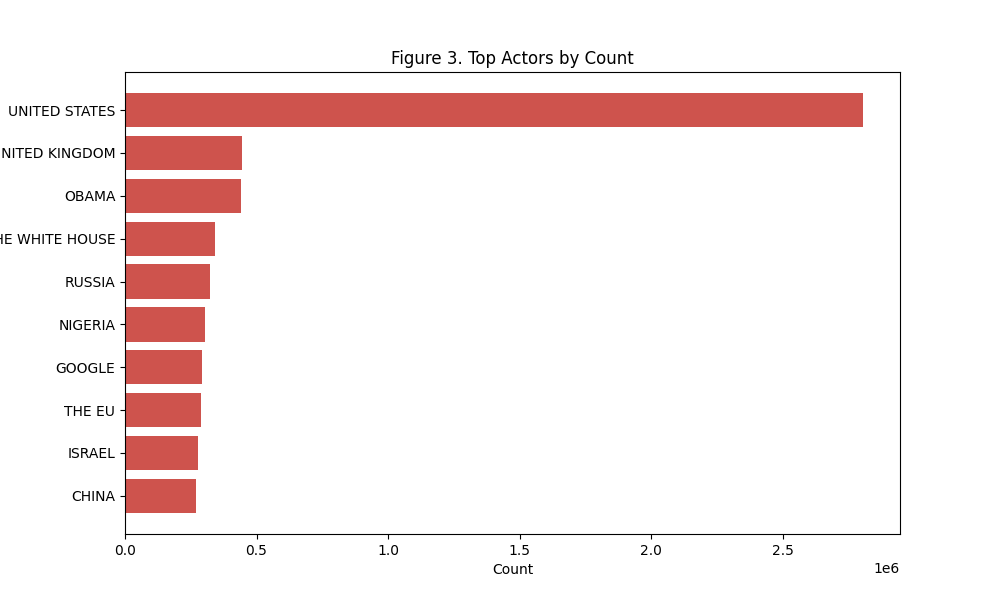

```python
top_actors = top_actors.sort_values(by="count", ascending=True);

plt.figure(figsize=(10, 6))
plt.barh(top_actors["Actor1Name"], top_actors["count"], color="#CE534D")
plt.xlabel("Count")
plt.ylabel("Actor")
plt.title("Figure 3. Top Actors by Count")
plt.show();

%matplot plt
```

- `United States` dominated the top 10 actors by count. This distribution highlights the importance of certain countries, organizations, and individuals in global news coverage.

#### Distribution of Goldenstein Scale Values

To understand the distribution of the Goldstein Scale values in our dataset, we plotted their distribution. The Goldstein Scale measures the impact of an event, with positive values indicating cooperative events and negative values indicating conflict events.

```python
# Group by GoldsteinScale and count the occurrences
goldstein_scale_counts = (df.groupBy("GoldsteinScale").count()
                          .orderBy("GoldsteinScale").toPandas());
goldstein_scale_counts["GoldsteinScale"] = (pd.to_numeric(
    goldstein_scale_counts["GoldsteinScale"]))
goldstein_scale_counts = (goldstein_scale_counts
                          .sort_values(by="GoldsteinScale"));
```

```
VBox()
```

```
FloatProgress(value=0.0, bar_style='info', description='Progress:', layout=Layout(height='25px', width='50%'),…
```

```
VBox()
```

```
FloatProgress(value=0.0, bar_style='info', description='Progress:', layout=Layout(height='25px', width='50%'),…
```

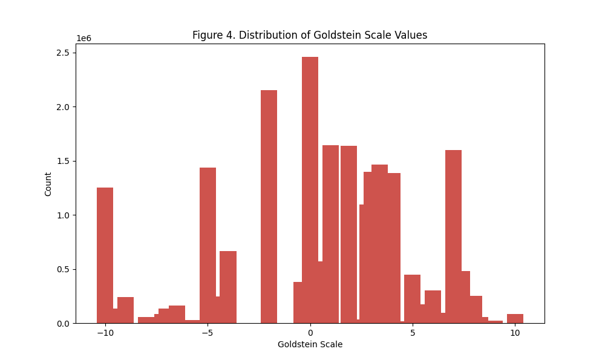

```python
plt.figure(figsize=(10, 6))
plt.bar(goldstein_scale_counts["GoldsteinScale"],
        goldstein_scale_counts["count"], color="#CE534D")
plt.xlabel("Goldstein Scale")
plt.ylabel("Count")
plt.title("Figure 4. Distribution of Goldstein Scale Values")
plt.show();

%matplot plt
```

### Data Preprocessing

As seen in the exploration, the columns: `Actor1Code`, `Actor1Name`, `Actor1CountryCode`, `Actor1Type1Code`, `IsRootEvent`, `EventCode`, `EventBaseCode`, `EventRootCode`, `QuadClass` has a string data typea. However, based on the [GDELT Data Format Documentation](http://data.gdeltproject.org/documentation/GDELT-Data_Format_Codebook.pdf), these columns should be treated as categorical. Therefore, we will apply `StringIndexer` to convert these column values to their respective indeces. Similarly, the `GoldsteinScale` and `NumMentions` should be treated sa double.

```python
si = StringIndexer(inputCols=["Actor1Code", "Actor1Name", "Actor1CountryCode",
                             "Actor1Type1Code", "IsRootEvent", "EventCode",
                             "EventBaseCode", "EventRootCode", "QuadClass"],
                   outputCols=["Actor1Code_ind", "Actor1Name_ind",
                               "Actor1CountryCode_ind", "Actor1Type1Code_ind",
                               "IsRootEvent_ind", "EventCode_ind",
                               "EventBaseCode_ind", "EventRootCode_ind",
                               'QuadClass_ind']);
```

```
VBox()
```

```
FloatProgress(value=0.0, bar_style='info', description='Progress:', layout=Layout(height='25px', width='50%'),…
```

```python
df1 = si.fit(df).transform(df);
```

```
VBox()
```

```
FloatProgress(value=0.0, bar_style='info', description='Progress:', layout=Layout(height='25px', width='50%'),…
```

```python
df2 = (df1.withColumn('GoldsteinScale', F.col('GoldsteinScale')
                      .cast('double'))
       .withColumn('NumMentions', F.col('NumMentions').cast('integer')));
```

```
VBox()
```

```
FloatProgress(value=0.0, bar_style='info', description='Progress:', layout=Layout(height='25px', width='50%'),…
```

However, given the nature of `StringIndexer`, which assigns the lowest index to the string value with the most frequent count, the ranking it introduces could potentially affect our predictions. Therefore, we should check for a correlation between these columns and the target column.

***Checking the correlation of the indexed columns and the target variable***

```python
cols = ["Actor1Code_ind", "Actor1Name_ind", "Actor1CountryCode_ind",
        "Actor1Type1Code_ind", "IsRootEvent_ind", "EventCode_ind",
        "EventBaseCode_ind", "EventRootCode_ind", 'QuadClass_ind'];
```

```
VBox()
```

```
FloatProgress(value=0.0, bar_style='info', description='Progress:', layout=Layout(height='25px', width='50%'),…
```

```python
for col in cols:
    correlation = df2.stat.corr(col, "NumMentions")
    print(f'The correlation of {col} and NumMentions is: {correlation}');
```

```
VBox()
```

```
FloatProgress(value=0.0, bar_style='info', description='Progress:', layout=Layout(height='25px', width='50%'),…
```

```
The correlation of Actor1Code_ind and NumMentions is: -0.0129169833374202
The correlation of Actor1Name_ind and NumMentions is: -0.003893128360805753
The correlation of Actor1CountryCode_ind and NumMentions is: -0.016246003250367017
The correlation of Actor1Type1Code_ind and NumMentions is: -0.013772536197141926
The correlation of IsRootEvent_ind and NumMentions is: -0.016663317799161543
The correlation of EventCode_ind and NumMentions is: 0.0021056688805185845
The correlation of EventBaseCode_ind and NumMentions is: 0.0032826339793910098
The correlation of EventRootCode_ind and NumMentions is: 0.007896458455491154
The correlation of QuadClass_ind and NumMentions is: 0.011706278350901348
```

The correlation between the columns and `NumMentions` suggests a weak linear relationship, as most values cluster around 0. Consequently, the `StringIndexer` ranking should have minimal impact on our predictions.

***Checking the distribution of NumMentions***

```python
df2.select('NumMentions').summary().show();
```

```
VBox()
```

```
FloatProgress(value=0.0, bar_style='info', description='Progress:', layout=Layout(height='25px', width='50%'),…
```

```
+-------+------------------+
|summary|       NumMentions|
+-------+------------------+
|  count|          22704441|
|   mean|13.418690422723907|
| stddev| 71.47719341808244|
|    min|                 1|
|    25%|                 2|
|    50%|                 4|
|    75%|                10|
|    max|             34810|
+-------+------------------+
```

Looking at the summary of the `NumMentions` it seems that until 75% of the dataset, the NumMentions values are still around 10, while the max is way more than the value of 75% tile.

```python
df2.select('NumMentions').filter(F.col('NumMentions') > 10).summary().show();
```

```
VBox()
```

```
FloatProgress(value=0.0, bar_style='info', description='Progress:', layout=Layout(height='25px', width='50%'),…
```

```
+-------+------------------+
|summary|       NumMentions|
+-------+------------------+
|  count|           3541844|
|   mean| 62.91074310443938|
| stddev|172.63661222158382|
|    min|                11|
|    25%|                15|
|    50%|                21|
|    75%|                46|
|    max|             34810|
+-------+------------------+
```

Again, examining the summary of `NumMentions` after filtering for values greater than 10, we can still see a large gap. This indicates that `NumMentions` is highly right-skewed. To address the skewness of the target variable, we will apply a logarithmic transformation.

***Applying log transformation on the `NumMentions`***

```python
df3 = df2.withColumn("NumMentions1", F.log1p(df2["NumMentions"]));
```

```
VBox()
```

```
FloatProgress(value=0.0, bar_style='info', description='Progress:', layout=Layout(height='25px', width='50%'),…
```

Lets check again its distribution

```python
splits = [float('-inf'), 1, 2, 3, 4, float('inf')];
```

```
VBox()
```

```
FloatProgress(value=0.0, bar_style='info', description='Progress:', layout=Layout(height='25px', width='50%'),…
```

```python
bucketizer = Bucketizer(splits=splits,
                        inputCol='NumMentions1',
                        outputCol='bins');
```

```
VBox()
```

```
FloatProgress(value=0.0, bar_style='info', description='Progress:', layout=Layout(height='25px', width='50%'),…
```

```python
binned_df = bucketizer.transform(df3);
```

```
VBox()
```

```
FloatProgress(value=0.0, bar_style='info', description='Progress:', layout=Layout(height='25px', width='50%'),…
```

```python
binned_counts = binned_df.groupBy('bins').count().orderBy('bins').toPandas();
```

```
VBox()
```

```
FloatProgress(value=0.0, bar_style='info', description='Progress:', layout=Layout(height='25px', width='50%'),…
```

```
VBox()
```

```
FloatProgress(value=0.0, bar_style='info', description='Progress:', layout=Layout(height='25px', width='50%'),…
```

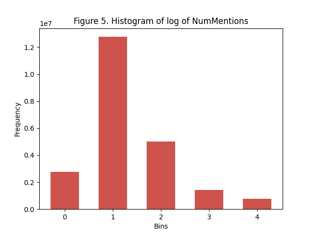

```python
plt.close()
plt.bar(binned_counts['bins'], binned_counts['count'],
        width=0.6, color='#CE534D')
plt.xlabel('Bins')
plt.ylabel('Frequency')
plt.title('Figure 5. Histogram of log of NumMentions')
plt.show();
%matplot plt
```

```python
df3.select('NumMentions1').summary().show();
```

```
VBox()
```

```
FloatProgress(value=0.0, bar_style='info', description='Progress:', layout=Layout(height='25px', width='50%'),…
```

```
+-------+------------------+
|summary|      NumMentions1|
+-------+------------------+
|  count|          22704441|
|   mean|1.8160346845451916|
| stddev| 0.939356189965669|
|    min|0.6931471805599453|
|    25%|1.0986122886681096|
|    50%|1.6094379124341003|
|    75%|2.3978952727983707|
|    max|10.457688707770052|
+-------+------------------+
```

With the log transformation we were able to reduce the skewness of the dataset and can be used for now as a target variable for prediction.

***Applying vector assembler and min max scaler to the feature and target***

In Machine Learning of big data, the accepted column is on the form of vector, hence we will vectorize all feature columns so that we may be able to use the machine learning of big data, moreover to reduce the range of the the vector and target variable and avoid the impact of high index categories we will apply `MinMaxScaler`

```python
cols = ['GoldsteinScale', 'Actor1Code_ind','Actor1Name_ind',
        'Actor1CountryCode_ind', 'Actor1Type1Code_ind', 'IsRootEvent_ind',
        'EventCode_ind','EventBaseCode_ind', 'EventRootCode_ind',
        'QuadClass_ind'];
```

```
VBox()
```

```
FloatProgress(value=0.0, bar_style='info', description='Progress:', layout=Layout(height='25px', width='50%'),…
```

Set up the VectorAssembler and MinMaxScaler for both features and target.

```python
v_assembler = VectorAssembler(inputCols=cols,
                              outputCol="assembledFeatures",
                              handleInvalid='skip');
mms = MinMaxScaler(inputCol="assembledFeatures",
                          outputCol="scaledFeatures");
v_target = VectorAssembler(inputCols=["NumMentions1"],
                              outputCol="NumMentionsvec",
                              handleInvalid='skip');
mms_target = MinMaxScaler(inputCol="NumMentionsvec",
                          outputCol="target");
```

```
VBox()
```

```
FloatProgress(value=0.0, bar_style='info', description='Progress:', layout=Layout(height='25px', width='50%'),…
```

Since MinMaxScaler expects a vector as input, we need to use a UDF (User-Defined Function) to extract the target variable from its vector form before scaling. This is necessary because the target variable should be a double type during prediction.

```python
unlist = F.udf(lambda x: round(float(list(x)[0]),3), DoubleType());
```

```
VBox()
```

```
FloatProgress(value=0.0, bar_style='info', description='Progress:', layout=Layout(height='25px', width='50%'),…
```

```python
train_data, test_data = df3.randomSplit([0.8, 0.2], seed=42);
```

```
VBox()
```

```
FloatProgress(value=0.0, bar_style='info', description='Progress:', layout=Layout(height='25px', width='50%'),…
```

```python
train = v_target.transform(train_data);
train1 = mms_target.fit(train).transform(train);
train_data_1 = train1.withColumn('target', unlist(F.col('target')));
```

```
VBox()
```

```
FloatProgress(value=0.0, bar_style='info', description='Progress:', layout=Layout(height='25px', width='50%'),…
```

```python
test = v_target.transform(test_data);
test = mms_target.fit(train).transform(test);
test_data_1 = test.withColumn('target', unlist(F.col('target')));
```

```
VBox()
```

```
FloatProgress(value=0.0, bar_style='info', description='Progress:', layout=Layout(height='25px', width='50%'),…
```

```python
td1 = v_assembler.transform(train_data_1);
td2 = mms.fit(td1).transform(td1);
```

```
VBox()
```

```
FloatProgress(value=0.0, bar_style='info', description='Progress:', layout=Layout(height='25px', width='50%'),…
```

```python
ts1 = v_assembler.transform(test_data_1);
ts2 = mms.fit(td1).transform(ts1);
```

```
VBox()
```

```
FloatProgress(value=0.0, bar_style='info', description='Progress:', layout=Layout(height='25px', width='50%'),…
```

#### Save the datasets (Optional)

```python
# (td2.write.parquet('s3://bdcc2024-fp/train_parquet',
#                    mode='overwrite',
#                    partitionBy=['SQLDATE', 'Year']));

# (ts2.write.parquet('s3://bdcc2024-fp/test_parquet',
#                    mode='overwrite',
#                    partitionBy=['SQLDATE', 'Year']));
```

```
VBox()
```

```
FloatProgress(value=0.0, bar_style='info', description='Progress:', layout=Layout(height='25px', width='50%'),…
```

*Note: Uncomment it if you want to run it.*

### Loading the Train and Test dataset

Now, we load the train and test data.

```python
train_df = (spark.read.parquet('s3://bdcc2024-fp/train_parquet'));
test_df = (spark.read.parquet('s3://bdcc2024-fp/test_parquet'));
```

```
VBox()
```

```
FloatProgress(value=0.0, bar_style='info', description='Progress:', layout=Layout(height='25px', width='50%'),…
```

The Dataset now is properly split and the necessary columns where properly arranged we could now create our Machine Model pipeline.

### Machine Learning Models

To predict the number of mentions in the GDELT dataset, we implemented two machine learning models: `Linear Regression` and `Random Forest Regressor`.

Linear Regression is a straightforward and interpretable model that can provide insights into the relationships between features and the target variable. Meanwhile, Random Forest Regression is known for its robustness and ability to handle non-linear data.

```python
lr = LinearRegression(featuresCol="scaledFeatures",
                           labelCol="target");
rf = RandomForestRegressor(featuresCol="scaledFeatures",
                           labelCol="target");
```

```
VBox()
```

```
FloatProgress(value=0.0, bar_style='info', description='Progress:', layout=Layout(height='25px', width='50%'),…
```

#### Pipeline Setup

To streamline the modeling process and ensure consistency, we created pipelines for each model. The pipelines integrate the models with the necessary preprocessing steps.

```python
pipe_lr = Pipeline(stages=[lr]);
pipe_rf = Pipeline(stages=[rf]);
```

```
VBox()
```

```
FloatProgress(value=0.0, bar_style='info', description='Progress:', layout=Layout(height='25px', width='50%'),…
```

#### Hyperparameter Tuning with Grid Search

To optimize the performance of our models, we performed hyperparameter tuning using Grid Search. This process involves systematically varying the hyperparameters to find the best combination.

```python
paramGrid_lr = (ParamGridBuilder()
             .addGrid(lr.elasticNetParam, [0, 1])
             .addGrid(lr.maxIter, [50, 100, 200, 500])
             .addGrid(lr.solver, ['auto', 'normal', 'l-bfgs'])
             .build());

paramGrid_rf = (ParamGridBuilder()
                .addGrid(rf.maxBins, [5, 15])
                .addGrid(rf.maxDepth, [5, 15])
                .addGrid(rf.featureSubsetStrategy, ['sqrt', 'log2'])
                .build());
```

```
VBox()
```

```
FloatProgress(value=0.0, bar_style='info', description='Progress:', layout=Layout(height='25px', width='50%'),…
```

#### Model Evaluation and Cross-Validation

To evaluate the performance of our models, we used the Mean Absolute Error (MAE) metric. Lower MAE values indicate better model performance. Also, to ensure the robustness of our model evaluations, we employed 3-fold cross-validation.

```python
evaluator = RegressionEvaluator(labelCol="target",
                                predictionCol="prediction",
                                metricName='mae');

crossval_lr = CrossValidator(estimator=pipe_lr,
                          estimatorParamMaps=paramGrid_lr,
                          evaluator=evaluator,
                          numFolds=3);

crossval_rf = CrossValidator(estimator=pipe_rf,
                          estimatorParamMaps=paramGrid_rf,
                          evaluator=evaluator,
                          numFolds=3);
```

```
VBox()
```

```
FloatProgress(value=0.0, bar_style='info', description='Progress:', layout=Layout(height='25px', width='50%'),…
```

#### Model Training and Saving

After setting up, the next step was to train them on the training dataset and save the trained models for future use. The trained models were saved to an Amazon S3 bucket for easy access and deployment.

```python
cv_model_lr = crossval_lr.fit(train_df);
cv_model_rf = crossval_rf.fit(train_df);
```

```
VBox()
```

```
FloatProgress(value=0.0, bar_style='info', description='Progress:', layout=Layout(height='25px', width='50%'),…
```

```python
# cv_model_lr.write().overwrite().save('s3://bdcc2024-fp/trained_model_lr');
# cv_model_rf.write().overwrite().save('s3://bdcc2024-fp/trained_model_rf');
```

```
VBox()
```

```
FloatProgress(value=0.0, bar_style='info', description='Progress:', layout=Layout(height='25px', width='50%'),…
```

*Note: Uncomment it if you want to run it.*

### Baseline

```python
base_evaluator = RegressionEvaluator(labelCol="NumMentions",
                                predictionCol="pred",
                                metricName='mae');
```

```
VBox()
```

```
FloatProgress(value=0.0, bar_style='info', description='Progress:', layout=Layout(height='25px', width='50%'),…
```

```python
mean_value = train_df.select(F.mean(F.col('NumMentions'))).collect()[0][0];
```

```
VBox()
```

```
FloatProgress(value=0.0, bar_style='info', description='Progress:', layout=Layout(height='25px', width='50%'),…
```

```python
df_base = train_df.withColumn('pred', F.col('NumMentions') + mean_value);
```

```
VBox()
```

```
FloatProgress(value=0.0, bar_style='info', description='Progress:', layout=Layout(height='25px', width='50%'),…
```

```python
base_mae = base_evaluator.evaluate(df_base)
print(f'To beat: {base_mae}');
```

```
VBox()
```

```
FloatProgress(value=0.0, bar_style='info', description='Progress:', layout=Layout(height='25px', width='50%'),…
```

```
To beat: 13.419755422147599
```

### Model Testing

After training the models, we proceeded to test their performance on a separate test dataset. This step was essential to evaluate the models' ability to generalize to new, unseen data. We used the previously trained Linear Regression and Random Forest Regressor models to make predictions and then assessed their performance using the Mean Absolute Error (MAE) metric.

```python
lr = CrossValidatorModel.load("s3://bdcc2024-fp/trained_model_lr/");
rf = CrossValidatorModel.load("s3://bdcc2024-fp/trained_model_rf/");
```

```
VBox()
```

```
FloatProgress(value=0.0, bar_style='info', description='Progress:', layout=Layout(height='25px', width='50%'),…
```

```python
lr_test = lr.transform(test_df);
rf_test = rf.transform(test_df);
```

```
VBox()
```

```
FloatProgress(value=0.0, bar_style='info', description='Progress:', layout=Layout(height='25px', width='50%'),…
```

```python
best_mae_lr = evaluator.evaluate(lr_test);
best_mae_rf = evaluator.evaluate(rf_test);
```

```
VBox()
```

```
FloatProgress(value=0.0, bar_style='info', description='Progress:', layout=Layout(height='25px', width='50%'),…
```

```python
print(f'best MAE for LR: {best_mae_lr}\n'
      f'best MAE for RF: {best_mae_rf}\n');
```

```
VBox()
```

```
FloatProgress(value=0.0, bar_style='info', description='Progress:', layout=Layout(height='25px', width='50%'),…
```

```
best MAE for LR: 0.07775237209600401
best MAE for RF: 0.07298351177302512
```

Given the MAE (Mean Absolute Error), we'd like to understand the actual error in the scale of NumMentions. To achieve this, we can follow these steps:

Since MAE is a normalized value, we want to convert it back to the scale of `NumMentions`. We can achieve this by obtaining the minimum and maximum values of `NumMentions` in the training data.

```python
max_value = train_data.select(F.max('NumMentions1')).collect()[0][0];
min_value = train_data.select(F.min('NumMentions1')).collect()[0][0];
```

```
VBox()
```

```
FloatProgress(value=0.0, bar_style='info', description='Progress:', layout=Layout(height='25px', width='50%'),…
```

```python
inv_mae_lr = best_mae_lr*(max_value-min_value)+min_value;
inv_mae_rf = best_mae_rf*(max_value-min_value)+min_value;
```

```
VBox()
```

```
FloatProgress(value=0.0, bar_style='info', description='Progress:', layout=Layout(height='25px', width='50%'),…
```

```python
scaled_lr = math.expm1(inv_mae_lr);
scaled_rf = math.expm1(inv_mae_rf);
```

```
VBox()
```

```
FloatProgress(value=0.0, bar_style='info', description='Progress:', layout=Layout(height='25px', width='50%'),…
```

```python
print(f'The orignal MAE value for LR is; {scaled_lr}\n'
      f'The original MAE value for RF is: {scaled_rf}');
```

```
VBox()
```

```
FloatProgress(value=0.0, bar_style='info', description='Progress:', layout=Layout(height='25px', width='50%'),…
```

```
The orignal MAE value for LR is; 2.9961190037442313
The original MAE value for RF is: 2.8300188416739296
```

```python
print(f'Since our baseline is: {base_mae}\n'
      f'We were able to have a prediction model with less errors');
```

```
VBox()
```

```
FloatProgress(value=0.0, bar_style='info', description='Progress:', layout=Layout(height='25px', width='50%'),…
```

```
Since our baseline is: 13.419755422147599
We were able to have a prediction model with less errors
```

### Feature Importance

Given that RandomForest gave us the least error we would like to explore how Random Forest did its prediction and which columns affects its decision the most.

```python
importances = rf.bestModel.stages[-1].featureImportances;
importances_dict = {name: importance for name,
                    importance in zip(cols, importances.toArray())};
importances_dict = sorted(importances_dict.items(), key=lambda x: x[1], reverse=True);
```

```
VBox()
```

```
FloatProgress(value=0.0, bar_style='info', description='Progress:', layout=Layout(height='25px', width='50%'),…
```

```python
for feature, importance in importances_dict:
    print(f"{feature}: {importance}");
```

```
VBox()
```

```
FloatProgress(value=0.0, bar_style='info', description='Progress:', layout=Layout(height='25px', width='50%'),…
```

```
Actor1Name_ind: 0.4513245042873958
Actor1CountryCode_ind: 0.14758520629113034
Actor1Code_ind: 0.11456315003588273
Actor1Type1Code_ind: 0.11207913041166473
IsRootEvent_ind: 0.07550429142079859
EventRootCode_ind: 0.025116029280128748
EventBaseCode_ind: 0.021984777963776948
GoldsteinScale: 0.019504968117323822
EventCode_ind: 0.018790053394154217
QuadClass_ind: 0.013547888797744082
```

# Results and Discussion

**Table 2. Summary of Model Results**

| Model | Mean Absolute Error |
| --- | --- |
| Naive Baseline | 13. 4198 |
| Linear Regression | 2. 9961 |
| Random Forest Regression | 2.8300 |

**Table 3. Top 3 Most Important Feature**

| Feature | Value |
| --- | --- |
| Actor1 Name | 0.4513 |
| Actor1 Country Code | 0.1476 |
| Actor1 Code | 0.1146 |

The Feature Importances for the best performing model were used to identify important columns with the data that contributes the most to our predictions. Since these columns were converted into string indexes in pyspark, they are ordered according to frequency in the original data, and so feature importances can be used to isolate the impact of frequency of a certain actor or event code and feature to the NumMentions. According to this, this shows that the frequency of an actor, which could also be related to the importance or newsworthiness of an actor, is quite highly correlated and impacts the number of mentions or news importance of an event. Likewise, this is true for the country code where events happening in countries with more events and most likely large populations that are interested in these events is more likely to be mentioned multiple times.

# Conclusion

Based on the result, we are able to create a model that can predict the number of mentions with an average error of under 3. This is quite a good result with a significant improvement over the baseline with an average error of 13, and shows that the features that are in GDELT are actually able to capture important factors that affect news importance. The top three features that affect the number of mentions are isolated into the Actor1Name, Actor1CountryCode, and the Actor1Code. Since these are all string indexes, that means that it is the frequency of the item which is correlated with the importance of the event in the news. Most likely, this is because the most attention grabbing events and actors are also the most commonly covered and mentioned events. What is surprising is that the goldstein score which is meant to be a measurement of the impact of conflict or cooperation is very low on feature importance and has low predictive power of event importance.

# Recommendation

For further studies we recommend some approaches that could enhance the training model and possibly improve the results.

1. Data Cleaning and Feature Engineering can be approached now with more context. Since we know that frequency of the actor's names can affect the event's perceived importance, including actor2 columns but sharing their string index with actor1 columns could capture events done to high frequency or importance actors by unimportant or uncommon actors which would also trigger more mentions. Similarly, we can try to feature engineer the Event columns to bin and collect some similar kinds of events together based on their frequencies to reduce the number of unique event codes and create a more learnable feature for the models.
2. Events are interrelated, and if we can capture if certain events in a sequence are related to high impact events, this could also improve the model results. This could be a kind of feature engineering where the number of mentions for events that are mentioned in an article are used as an input feature for its own NumMentions.
3. The models used in this study are relatively simple and straightforward. By using more complex machine learning models such as Neural Networks, it may be possible to improve the results as well.

# Acknowledgement

We would like to express my sincere gratitude to Professor Christian Alis, Professor K-ann Carandang, and Professor Leo Lorenzo for their invaluable guidance and support throughout this project. Their expertise and encouragement have been instrumental in the successful completion of this study.

We would also like to acknowledge the assistance of ChatGPT, which was used to enhance the quality and clarity of the writing this report.

# References

- IDC. (2017). Data Age 2025. Retrieved fromRetrieved from https://www.seagate.com/www-content/our-story/trends/files/Seagate-WP-DataAge2025-March-2017.pdf
- GDELT Project. (n.d.). About Us. Retrieved fromRetrieved from https://gdeltproject.org/
- AWS Marketplace. Global Database of Events, Language and Tone (GDELT). Retrieved from https://aws.amazon.com/marketplace/pp/prodview-fmgfyur32mb3m
- GDELT Project. (n.d.). GDELT Data Format Codebook. gdeltproject.org. Retrieved from http://data.gdeltproject.org/documentation/GDELT-Data_Format_Codebook.pdf